# Notebook 21 – Solutions

## Getting Started

Before running this notebook, select “Session > Restart R and Clear Output” in the menu above to start a new R session. This will clear any old data sets and give us a blank slate to start with.

## French COVID-19

### Load the Data

We will be using the same datasets from the previous notebooks:

```r
dept <- read_sf(file.path("data", "france_departement.geojson"))
pop <- read_csv(file.path("data", "france_departement_population.csv"))
covid <- read_csv(file.path("data", "france_departement_covid.csv"))
```

This time, we will look into the temporal components of the data and see how they can be integrated into the spatial visualisations.

## Practice

### Plotting the spread of COVID-19 in the Rhône

Plot a line graph showing the number of patients hospitalised (y-axis) over time (x-axis) for the departement number 69 (“Rhône”).

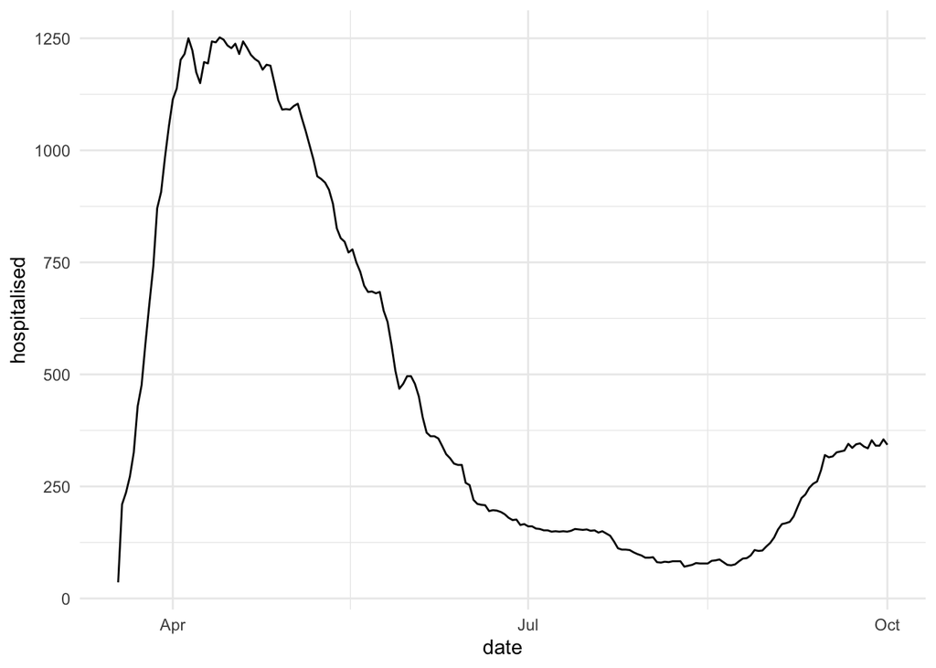

```r
covid %>%
  filter(departement == 69) %>%
  ggplot(aes(date, hospitalised)) +
    geom_line()
```

Take the plot from the previous question and change the date breaks and labels to label each month with its full name.

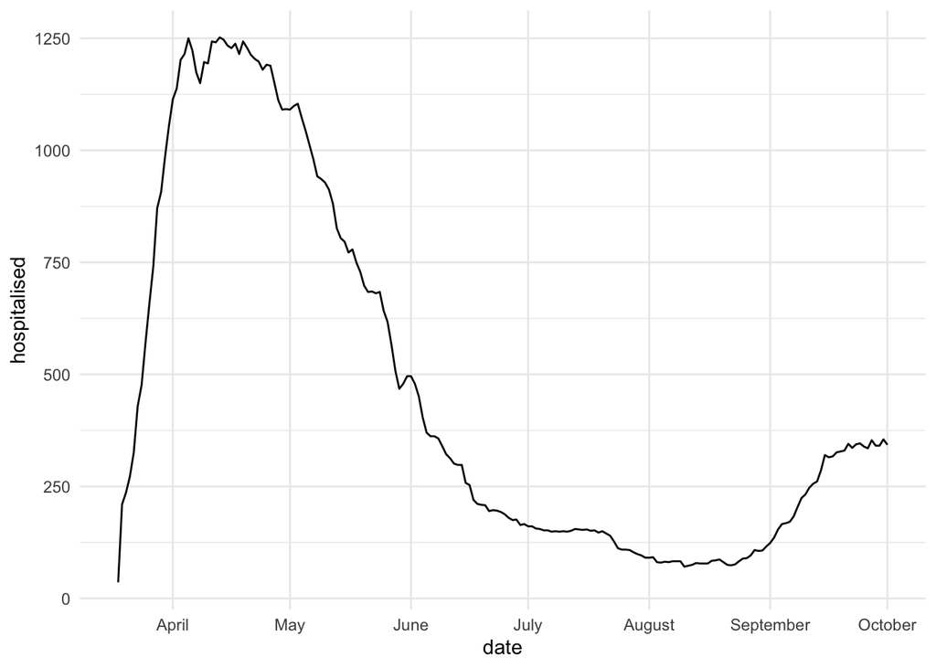

```r
covid %>%
  filter(departement == 69) %>%
  ggplot(aes(date, hospitalised)) +
    geom_line() +
    scale_x_date(date_breaks = "month", date_minor_breaks = "month", date_labels = "%B")
```

Now, we want to compare this to the number of deaths each day. However, the `deceased` is a total count rather than the new number of deaths. Use the `lag` function to add a `deceased_new` variable to the data from département number 69:

```r
covid %>%
  filter(departement == 69) %>%
  mutate(deceased_new = deceased - lag(deceased, n = 1))
```

```
## # A tibble: 198 × 10
##    date       departement departement_name deceased hospitalised reanimation
##    <date>     <chr>       <chr>               <dbl>        <dbl>       <dbl>
##  1 2020-03-18 69          Rhône                   0           36           8
##  2 2020-03-19 69          Rhône                  12          210          33
##  3 2020-03-20 69          Rhône                  19          236          41
##  4 2020-03-21 69          Rhône                  21          272          41
##  5 2020-03-22 69          Rhône                  26          326          48
##  6 2020-03-23 69          Rhône                  34          429          71
##  7 2020-03-24 69          Rhône                  42          476          87
##  8 2020-03-25 69          Rhône                  52          570         116
##  9 2020-03-26 69          Rhône                  65          658           0
## 10 2020-03-27 69          Rhône                  82          741         139
## # … with 188 more rows, and 4 more variables: recovered <dbl>,
## #   hospitalised_new <dbl>, reanimation_new <dbl>, deceased_new <dbl>
```

Now, produce a plot that shows the number of newly deceased people in département 69 over time:

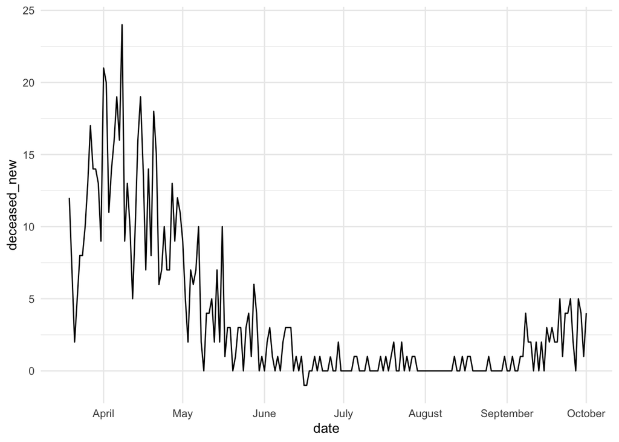

```r
covid %>%
  filter(departement == 69) %>%
  mutate(deceased_new = deceased - lag(deceased, n = 1) )%>%
  ggplot(aes(date, deceased_new)) +
    geom_line() +
    scale_x_date(date_breaks = "month", date_minor_breaks = "month", date_labels = "%B")
```

This plot is noisy because of the (thankfully) much lower counts. Modify your code from above to produce a plot with a 7 day rolling average:

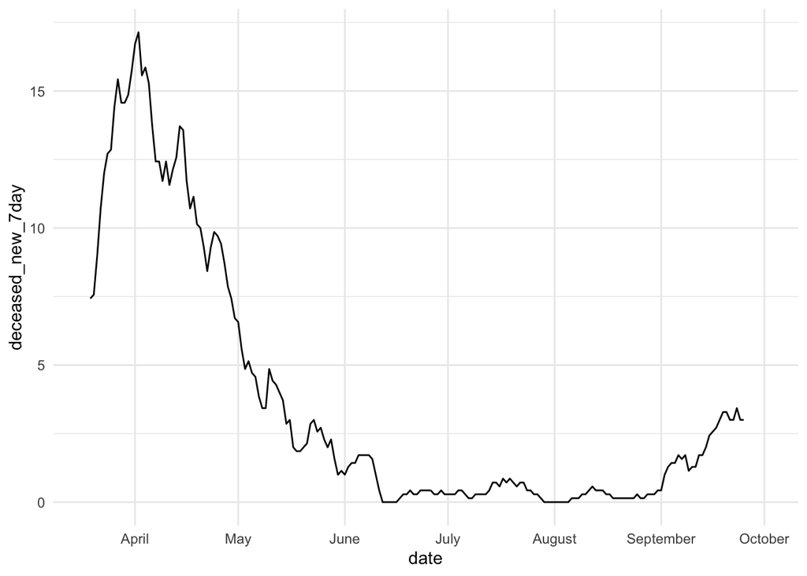

```r
covid %>%
  filter(departement == 69) %>%
  mutate(deceased_new = deceased - lag(deceased, n = 1) )%>%
  mutate(deceased_new_7day = roll_meanl(deceased_new, n = 7) )%>%
  ggplot(aes(date, deceased_new_7day)) +
    geom_line() +
    scale_x_date(date_breaks = "month", date_minor_breaks = "month", date_labels = "%B")
```

### Days of the Week: Reporting Bias?

Take the covid dataset, group by the date, take the sum (`sm_sum`) of the variable deceased across all the départements for each day, and add a variable `wday` giving the day of the week for each row of the data:

```r
covid %>%
  group_by(date) %>%
  summarize(sm_sum(deceased)) %>%
  mutate(wday = wday(date, label = TRUE, abbr = FALSE))
```

```
## # A tibble: 198 × 3
##    date       deceased_sum wday
##    <date>            <dbl> <ord>
##  1 2020-03-18          214 Wednesday
##  2 2020-03-19          317 Thursday
##  3 2020-03-20          441 Friday
##  4 2020-03-21          516 Saturday
##  5 2020-03-22          615 Sunday
##  6 2020-03-23          839 Monday
##  7 2020-03-24         1076 Tuesday
##  8 2020-03-25         1367 Wednesday
##  9 2020-03-26         1669 Thursday
## 10 2020-03-27         1965 Friday
## # … with 188 more rows
```

Starting with your code from the previous question, compute the change in the variable `deceased_sum` for each, and compute the average number of new deaths by the day of the week:

```r
covid %>%
  group_by(date) %>%
  summarize(sm_sum(deceased)) %>%
  mutate(wday = wday(date, label = TRUE, abbr = FALSE)) %>%
  mutate(deaths = deceased_sum - lag(deceased_sum,n = 1)) %>%
  group_by(wday) %>%
  summarize(sm_mean(deaths))
```

```
## # A tibble: 7 × 2
##   wday      deaths_mean
##   <ord>           <dbl>
## 1 Monday          123.
## 2 Tuesday         132.
## 3 Wednesday       125.
## 4 Thursday        105.
## 5 Friday          117.
## 6 Saturday         83.4
## 7 Sunday           64.6
```

What pattern do you see in the data? Do you have any concerns about the reporting method used in France?

### More Plotting Practice

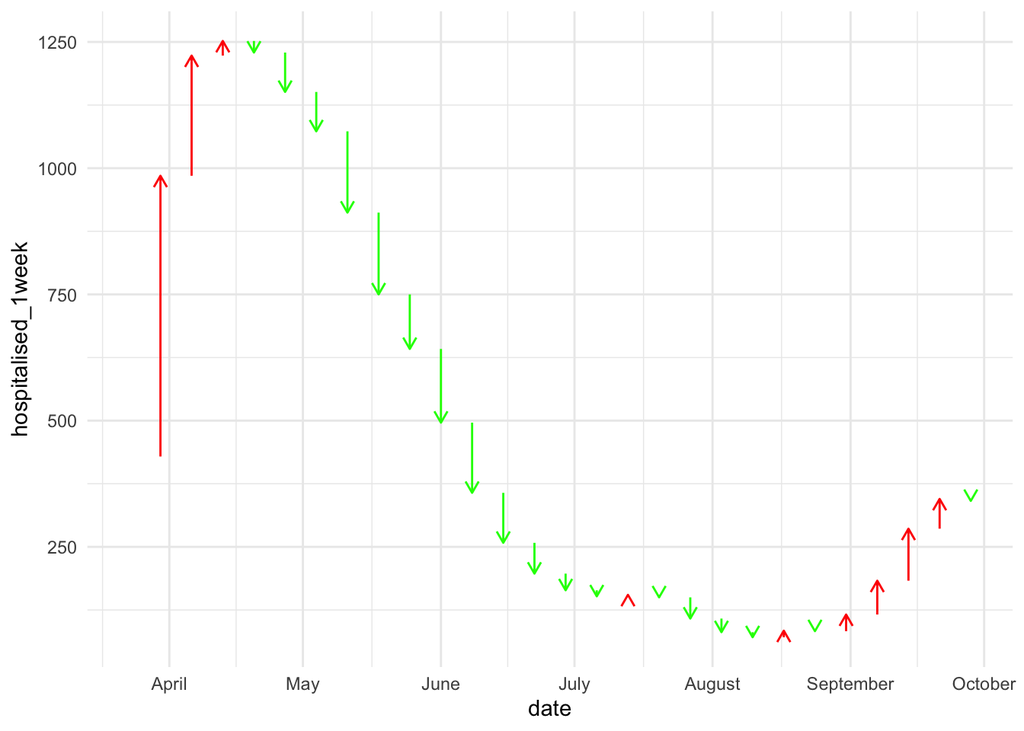

```r
covid %>%
  filter(departement == 69) %>%
  mutate(wday = wday(date)) %>%
  filter(wday == 1) %>%
  arrange(date) %>%
  mutate(
    hospitalised_1week = lag(hospitalised, n = 1),
    h_delta = hospitalised - hospitalised_1week,
    color = if_else(h_delta > 0, "red", "green")
  ) %>%
  ggplot(aes(date, hospitalised_1week)) +
    geom_segment(
      aes(xend = date, yend = hospitalised, color = color),
      arrow = arrow(length = unit(0.02, "npc"))
    ) +
    scale_x_date(date_breaks = "month", date_labels = "%B") +
    scale_color_identity()
```

You can change (hopefully easily) the département number and quickly see the changes for another region as well.